# Predicting remaining useful life for turbofan engines

### 3.2.2 Target variable (RUL)

We may finally examine the variable we want to predict:

#### 3.2.2.1 Simple dataset

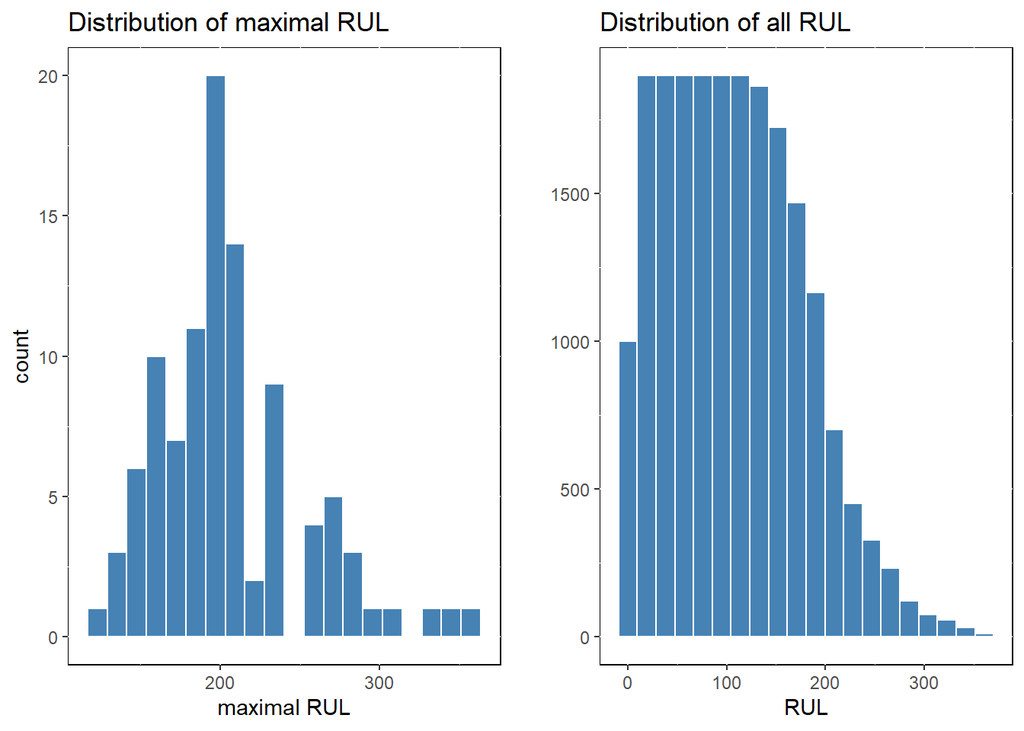

```r
# maximum RUL for simple ds
m_s <- data1 %>%
  group_by(unit_no) %>%
  summarise(max_RUL = max(RUL))%>%
  ggplot() +
  geom_histogram(aes(x = max_RUL), bins = 20, color = "white", fill = "steelblue")+
  ggtitle("Distribution of maximal RUL")+
  xlab("maximal RUL")+
  theme(panel.background  = NULL)

# all RUL simple
a_s <- data1 %>%
  ggplot() +
  geom_histogram(aes(x = RUL), bins = 20, color = "white", fill = "steelblue")+
  ggtitle("Distribution of all RUL")+
  theme(panel.background  = NULL)+
  ylab("")

ggarrange(m_s,a_s)
```

#### 3.2.2.2 Complicated dataset

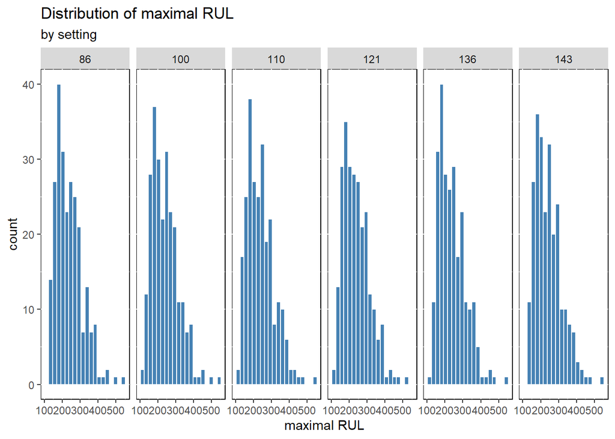

```r
# maximum RUL for simple ds
m_c <- data4 %>%
  group_by(unit_no,setting) %>%
  summarise(max_RUL = max(RUL))%>%
  ggplot() +
  geom_histogram(aes(x = max_RUL), bins = 20, color = "white", fill = "steelblue")+
  facet_grid(.~ setting)+
  ggtitle("Distribution of maximal RUL", subtitle = "by setting")+
  xlab("maximal RUL")+
  theme(panel.background  = NULL)


m_c
```

# 4 Modelling

```r
source("../../R/load_data.R")
load_data('rmd/sections/Modelling.Rmd')
```

```r
# function that validates a model on the out-of-sample data
get_validation_reg_score <- function(model,test_df,
                                     target_col = "act_RUL",
                                     drop_col=drop_cols){
  preds <- predict(model,test_df %>%
          select(-one_of(drop_col)))
reg_score <- postResample(preds,test_df[[target_col]])
return(reg_score)
}
```

```r
# function that plots predicted vs. actual RUL from the test set
plot_pred_vs_act <- function(model,test_df,
                                     target_col = "act_RUL",
                                     drop_col=drop_cols){
  preds <- predict(model,test_df %>%
          select(-one_of(drop_col)))
  act <- test_df[[target_col]]
  df <- as.data.frame(cbind('predicted' = preds,'actual' = act))

  over <- nrow(df[df$predicted>df$actual,])/nrow(df) %>% round(2)
  under <- nrow(df[df$predicted<df$actual,])/nrow(df)  %>% round(2)

  plot <- ggplot(df)+
    geom_point(aes(x=actual,y=predicted))+
    geom_abline(a=1,b=0, col = 'steelblue',linetype= 'dashed')+
    coord_fixed()+
    ggtitle("RUL: actual vs. predicted")+
    scale_x_continuous(breaks = round(seq(min(preds,act)-5,max(preds,act)-5,length.out = 5)))+
    scale_y_continuous(breaks = round(seq(min(preds,act)-5,max(preds,act)-5,length.out = 5)))+
    annotate('text',20,120,label=paste0("Over-estimation:\n" ,round(over*100),"% of cases"))+
    annotate('text',120,20,label=paste0("Under-estimation:\n" ,round(under*100),"% of cases"))

}
```

## 4.1 Two datasets

### 4.1.1 Simple dataset

Let’s try to limit the RUL. RUL may not be decreasing linearly. It may start to decrease only after a fault is developed. To model this situation, lets simply put a “cap” on the RUL, so that it is constant at the beginning and then starts to decrease linearly. Let’s see if it improves results.

We will experimentally choose the best “cap” by visually inspecting the relationship between mean sensor levels and RUL. As we can see, a “capped” RUL correlates better with the changing sensor levels, as initially they are rather stationary and start to “explode” only after some time.

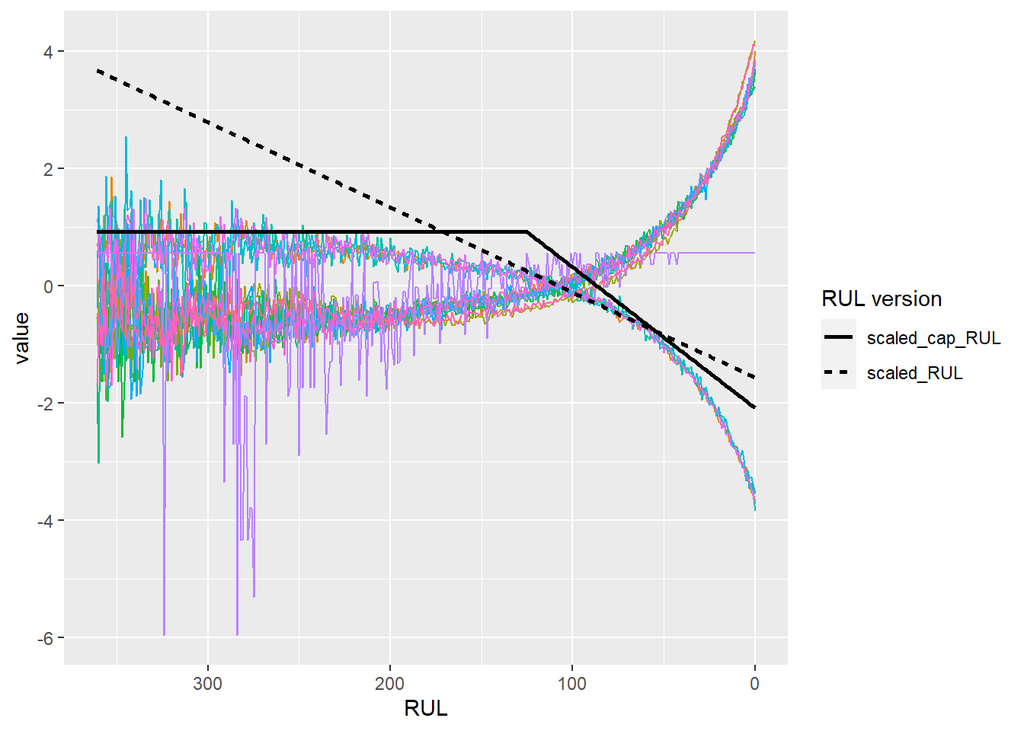

```r
cap_for_RUL <- 125
mean_sensors_df <- data1 %>%
  group_by(RUL) %>%
  summarise(across(starts_with("sensor"),mean)) %>%
  mutate(across(starts_with("sensor"),scale),
         scaled_RUL = scale(RUL)) %>%
  pivot_longer(-c(RUL,scaled_RUL))

RUL_df <- data1 %>%
  select(RUL) %>%
  mutate(cap_RUL = pmin(cap_for_RUL,RUL)) %>%
  mutate(across(ends_with("RUL"),scale,.names ="scaled_{.col}")) %>%
  pivot_longer(-c(RUL,cap_RUL)) %>%
  rename("RUL version" = "name")

  ggplot()+
  geom_line(data = mean_sensors_df ,aes(x=RUL,y=value,color=name), show.legend = F)+
  geom_line(data = RUL_df,aes(x=RUL,y=value,linetype=`RUL version`),size = 1)+
  scale_x_reverse()
```

The plot above presents relationship between RUL and a subset of sensors. The values are scaled so that they can be ploted on a single y axis.

#### 4.1.1.1 Baseline model

Our baseline model will be a simple linear regression with all the sensor data.

```r
set.seed(970416)
drop_cols <- colnames(data1)[1:5]
fitControl <- trainControl(## 10-fold CV
                           method = "repeatedcv",
                           number = 10,
                           ## repeated 10 times
                           repeats = 10)


baseline_trained_lm <- caret::train(RUL ~ ., data = data1 %>% select(-one_of(drop_cols)),
                 method = "lm",
                 trControl = fitControl)


baseline_score_simp <- get_validation_reg_score(baseline_trained_lm,test_data1_s)
print('Baseline RMSE in training is:')
baseline_trained_lm$results %>% arrange(RMSE)
```

```
## [1] "Baseline RMSE in training is:"
```

| intercept | RMSE | Rsquared | MAE | RMSESD | RsquaredSD | MAESD |
| --- | --- | --- | --- | --- | --- | --- |
| TRUE | 44.69033 | 0.579181 | 34.12574 | 0.6914363 | 0.00888506 | 0.5213953 |

Let’s see if it actually changes our baseline results:

```r
cap_for_RUL <- 125
data1_cap <- data1 %>% mutate(RUL = pmin(cap_for_RUL,RUL))
drop_cols <- colnames(data1)[1:5]


baseline_trained_cap <- caret::train(RUL ~ .,
                  data = data1_cap %>% select(-one_of(drop_cols)),
                  method = "lm")

baseline_score_cap_simp <- get_validation_reg_score(baseline_trained_cap,test_data1_s)

baseline_trained_cap$results %>% arrange(RMSE)
```

| intercept | RMSE | Rsquared | MAE | RMSESD | RsquaredSD | MAESD |
| --- | --- | --- | --- | --- | --- | --- |
| TRUE | 21.52204 | 0.7328222 | 17.59389 | 0.1195337 | 0.004415908 | 0.118946 |

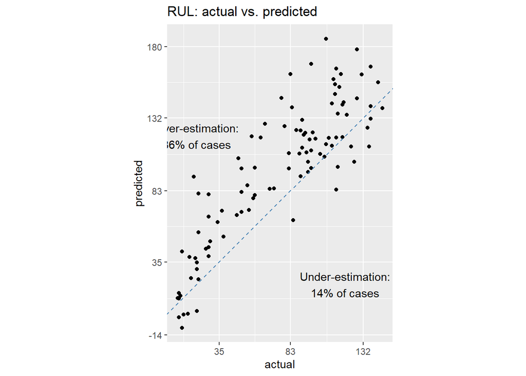

```r
print("Without capping RUL...")
(plot_pred_vs_act(baseline_trained_lm,test_data1_s))
```

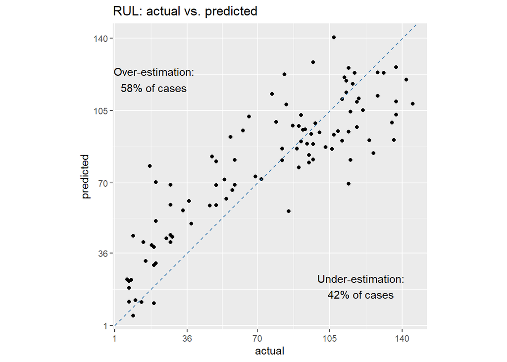

```
## [1] "Without capping RUL..."
## [1] "With capped RUL..."
```

```r
print("With capped RUL...")
(plot_pred_vs_act(baseline_trained_cap,test_data1_s))
```

The capping seems to be doing good work, the RMSE decreases more than 50%. Also the plot of predicted vs. actual looks way better for capped RUL. So let’s continue with capped RUL.

```r
cap_for_RUL <- 125
data1 <- data1 %>% mutate(RUL = pmin(cap_for_RUL,RUL))
```

#### 4.1.1.2 Random forest

We can now move on to fitting a more complex model. The chunk below performs a gridsearch over a grid of relevant parameters to find a configuration that minimizes the RMSE in a 5-fold CV. The object is then saved. The chunk is commented out, so that the report generates quickly.

```r
# set.seed(970416)
# drop_cols <- colnames(data1)[1:5]
#
# tune_grid <- expand.grid(
#   .mtry = c(2,4,6,8),
#   .splitrule = c("variance","extratrees","maxstat","beta"),
#   .min.node.size = c(20,50,100,150,200,400)
# )
# fitControl <- trainControl(## 5-fold CV
#                            method = "repeatedcv",
#                            number = 5,
#                            ## repeated 5 times
#                            repeats = 5,
#                            verboseIter = T)
#
#
# rf_trained_1 <- train(RUL ~ ., data = data1 %>% select(-one_of(drop_cols)),
#                  method = "ranger",
#                  trControl = fitControl,
#                  tuneGrid = tune_grid,
#                  num.trees = 500,
#                  verbose = T)
# rf_trained_1$results %>% arrange(RMSE)
# saveRDS(rf_trained_1,file = here("objects/rf_trained_04_01.rds"))
```

Below we evaluate the best fitted model after reading it from an RDS object.

```r
rf_fit <- readRDS(here("objects/rf_trained_04_01.rds"))
print("The RMSE for the best parametrization of Random Forest is...")
rf_fit$results %>% arrange(RMSE) %>% head(1) %>% .[['RMSE']]
```

```
## [1] "The RMSE for the best parametrization of Random Forest is..."
## [1] 17.95183
```

Let’s see the plot of predicted vs. actual RUL:

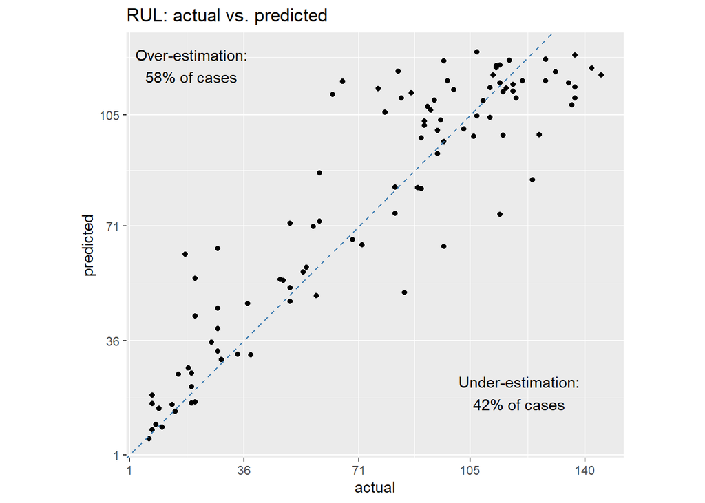

```r
(plot_pred_vs_act(rf_fit,test_data1_s))
```

We see that the capping has another advantage. The model now has smaller fraction of overestimating cases which is desirable feature in the context of the predictive maintanenece task.

#### 4.1.1.3 XGBoost

The second model is XGBoost. We also perform a gridsearch and save the object.

```r
# drop_cols <- colnames(data1)[1:5]
# # tune_grid <- expand.grid(nrounds=c(100,200,300,400),
# #                         max_depth = c(3:7),
# #                         eta = c(0.01,0.05,0.1,0.15,0.2),
# #                         gamma = c(0.01,0.05,0.1,0.15,0.2,0.5),
# #                         colsample_bytree = c(0.3,0.5,0.75,1),
# #                         subsample = c(0.2,0.5,0.7,0.8),
# #                         min_child_weight = c(0.2,0.7,1,1.3,1.8))
# tune_grid <- expand.grid(nrounds=c(100,400),
#                         max_depth = c(3:7),
#                         eta = c(0.01,0.2),
#                         gamma = c(0.01,0.5),
#                         colsample_bytree = c(0.5,0.75,1),
#                         subsample = c(0.5,0.8),
#                         min_child_weight = c(0,1))
#
# xgb_fit <- train(RUL ~.,
#                 data = data1 %>% select(-one_of(drop_cols)),
#                 method = "xgbTree",
#                 trControl=fitControl,
#                 tuneGrid = tune_grid
#                 )
#
# saveRDS(xgb_fit,here("objects/xgb_trained_04_01_B.rds"))
# xgb_fit$results %>% arrange(RMSE)
```

```r
xgb_fit <- readRDS(here("objects/xgb_trained_04_01_B.rds"))
print("The RMSE for the best parametrization of XGBoost is...")
xgb_fit$results %>% arrange(RMSE) %>% head(1) %>% .[['RMSE']]
```

```
## [1] "The RMSE for the best parametrization of XGBoost is..."
## [1] 18.02295
```

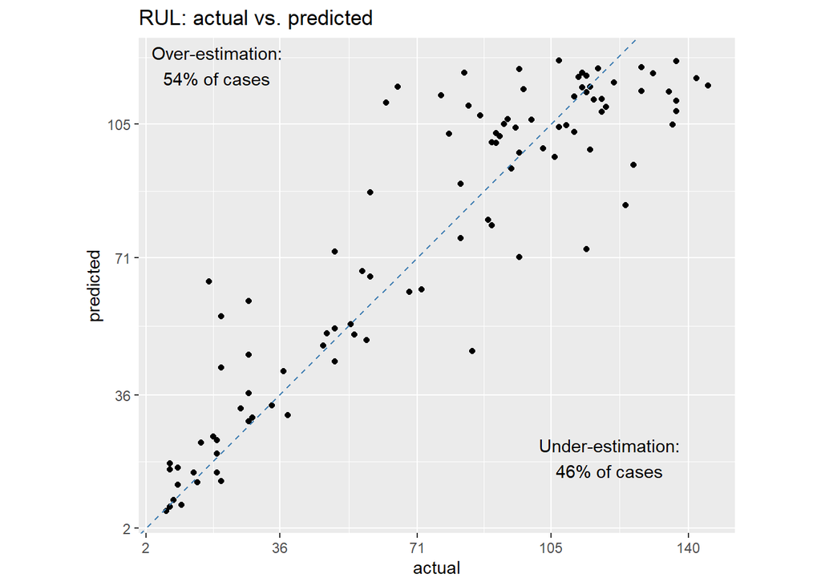

```r
(plot_pred_vs_act(xgb_fit,test_data1_s))
```

Even though we have a slightly higher RMSE than in case of Random FOrest, we do have a better ratio of over- to underestimaiton. Therefore, the model can still be taken into consideration.

### 4.1.2 Complicated dataset

Here we proceed with exactly the same steps as in case of the simple dataset. THe only difference is that we need to dummy columns to account for the different operational setitngs. The grid searches were of course carried out separately for the complicated dataset.

#### 4.1.2.1 Baseline model

Our baseline model will again be a simple linear regression.

```r
set.seed(970416)
add_dummies <- function(df,cols){
  dums <- fastDummies::dummy_cols(df[cols])%>% select(-one_of(c(cols)))

  df_out <- cbind(df,dums)

  df_out <- df_out %>% select(-one_of(c(cols)))
}


data4_dums <- add_dummies(data4,'setting')
test_data4_s_dums <- add_dummies(test_data4_s,'setting')
drop_cols <- c(colnames(data4_dums)[1:5],"setting")
dropfitControl <- trainControl(## 10-fold CV
                           method = "repeatedcv",
                           number = 10,
                           ## repeated 10 times
                           repeats = 10)


baseline_trained_lm <- caret::train(RUL ~ ., data = data4_dums %>% select(-one_of(drop_cols)),
                 method = "lm",
                 trControl = fitControl)


baseline_score_comp <- get_validation_reg_score(baseline_trained_lm,test_data4_s_dums)
baseline_trained_lm$results %>% arrange(RMSE)
```

| intercept | RMSE | Rsquared | MAE | RMSESD | RsquaredSD | MAESD |
| --- | --- | --- | --- | --- | --- | --- |
| TRUE | 60.30767 | 0.5488791 | 46.03806 | 0.6830278 | 0.006276727 | 0.4551644 |

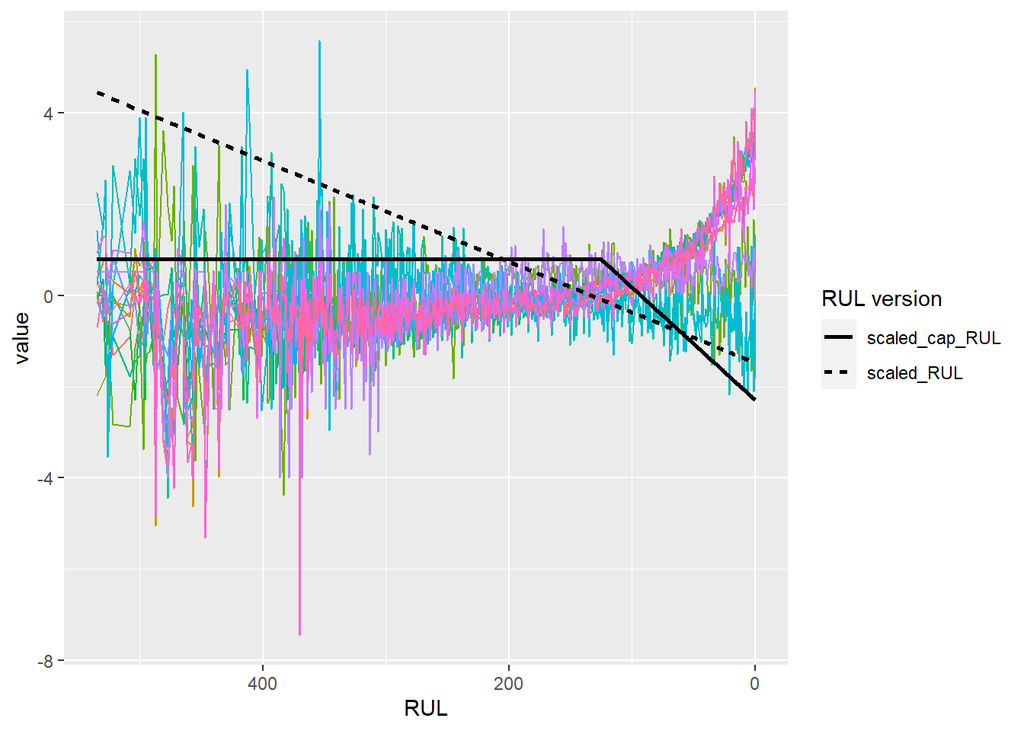

```r
cap_for_RUL <- 125
mean_sensors_df <- data4_dums %>% filter(setting_100 == 1) %>%
  group_by(RUL) %>%
  summarise(across(starts_with("sensor"),mean)) %>%
  mutate(across(starts_with("sensor"),scale),
         scaled_RUL = scale(RUL)) %>%
  pivot_longer(-c(RUL,scaled_RUL))

RUL_df <- data4_dums %>%  filter(setting_100 == 1) %>%
  select(RUL) %>%
  mutate(cap_RUL = pmin(cap_for_RUL,RUL)) %>%
  mutate(across(ends_with("RUL"),scale,.names ="scaled_{.col}")) %>%
  pivot_longer(-c(RUL,cap_RUL)) %>%
  rename("RUL version" = "name")

  ggplot()+
  geom_line(data = mean_sensors_df ,aes(x=RUL,y=value,color=name), show.legend = F)+
  geom_line(data = RUL_df,aes(x=RUL,y=value,linetype=`RUL version`),size = 1)+
  scale_x_reverse()
```

```r
data4_cap <- data4_dums %>% mutate(RUL = pmin(cap_for_RUL,RUL))
drop_cols <- colnames(data1)[1:5]

baseline_trained_cap_comp <- caret::train(RUL ~ .,
                  data = data4_cap %>% select(-one_of(drop_cols)),
                  method = "lm")

baseline_score_cap_comp <- get_validation_reg_score(baseline_trained_cap,test_data4_s_dums)

baseline_trained_cap_comp$results %>% arrange(RMSE)
```

| intercept | RMSE | Rsquared | MAE | RMSESD | RsquaredSD | MAESD |
| --- | --- | --- | --- | --- | --- | --- |
| TRUE | 21.48394 | 0.7205218 | 17.17373 | 0.1025459 | 0.003554008 | 0.08387685 |

Again we have a big gain in the CV.

#### 4.1.2.2 Random Forest

Proceed with the same grid search as in simple dataset case.

```r
# # TODO RUN HERE
# set.seed(970416)
# drop_cols <- colnames(data4_dums)[1:5]
#
# tune_grid <- expand.grid(
#   .mtry = c(2,4,6,8),
#   .splitrule = c("variance","extratrees","maxstat","beta"),
#   .min.node.size = c(20,50,100,150,200)
# )
# fitControl <- trainControl(## 5-fold CV
#                            method = "repeatedcv",
#                            number = 5,
#                            ## repeated 5 times
#                            repeats = 5,
#                            verboseIter = T)
#
#
# rf_trained_1 <- caret::train(RUL ~ ., data = data4_cap %>% select(-one_of(drop_cols)),
#                  method = "ranger",
#                  trControl = fitControl,
#                  tuneGrid = tune_grid,
#                  num.trees = 500,
#                  verbose = T)
# rf_trained_1$results %>% arrange(RMSE)
# saveRDS(rf_trained_1,file = here("objects/rf_trained_04_01_comp_cap.rds"))
```

Load the best model and see results:

```r
rf_fit <- readRDS(here("objects/rf_trained_04_01_comp_cap.rds"))
print("The RMSE for the best parametrization of Random Forest is...")
rf_fit$results %>% arrange(RMSE) %>% head(1) %>% .[['RMSE']]
```

```
## [1] "The RMSE for the best parametrization of Random Forest is..."
## [1] 17.24392
```

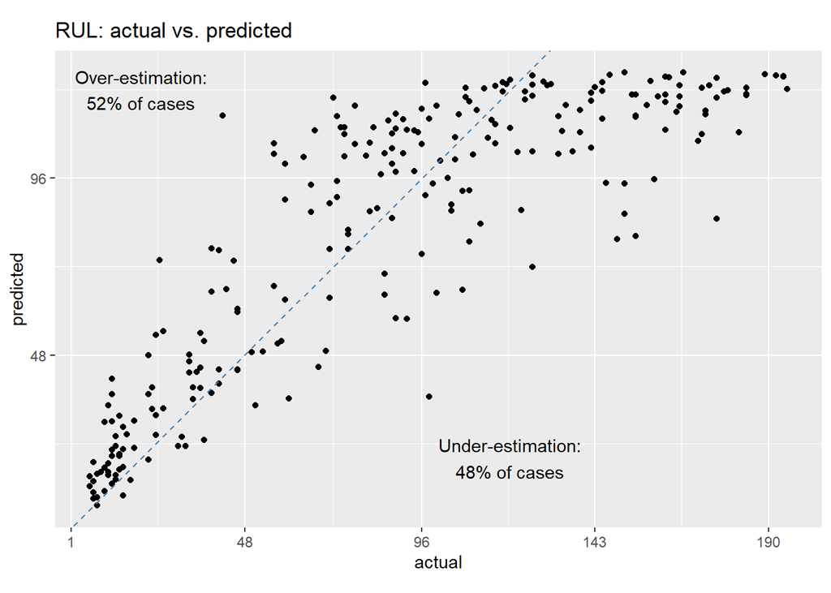

```r
(plot_pred_vs_act(rf_fit,test_data4_s_dums))
```

#### 4.1.2.3 XGBoost

Same procedure as for RF above

```r
# # TODO RUN HERE
# set.seed(970416)
# drop_cols <- colnames(data4_cap)[1:5]
# tune_grid <- expand.grid(nrounds=c(100,200,300,400),
#                         max_depth = c(3:7),
#                         eta = c(0.05, 1),
#                         gamma = c(0.01),
#                         colsample_bytree = c(0.75),
#                         subsample = c(0.50),
#                         min_child_weight = c(0))
#
# xgb_fit <- caret::train(RUL ~.,
#                 data = data4_cap %>% select(-one_of(drop_cols)),
#                 method = "xgbTree",
#                 trControl=fitControl,
#                 tuneGrid = tune_grid,
#                 tuneLength = 10)
#
# xgb_fit$results %>% arrange(RMSE)
# saveRDS(xgb_fit,here("objects/xgb_trained_04_01_comp_cap.rds"))
# xgb_fit$results %>% arrange(RMSE)
```

```r
xgb_fit <- readRDS(here("objects/xgb_trained_04_01_comp_cap.rds"))

print("The RMSE for the best parametrization of XGBoost is...")
xgb_fit$results %>% arrange(RMSE) %>% head(1) %>% .[['RMSE']]
```

```
## [1] "The RMSE for the best parametrization of XGBoost is..."
## [1] 17.38151
```

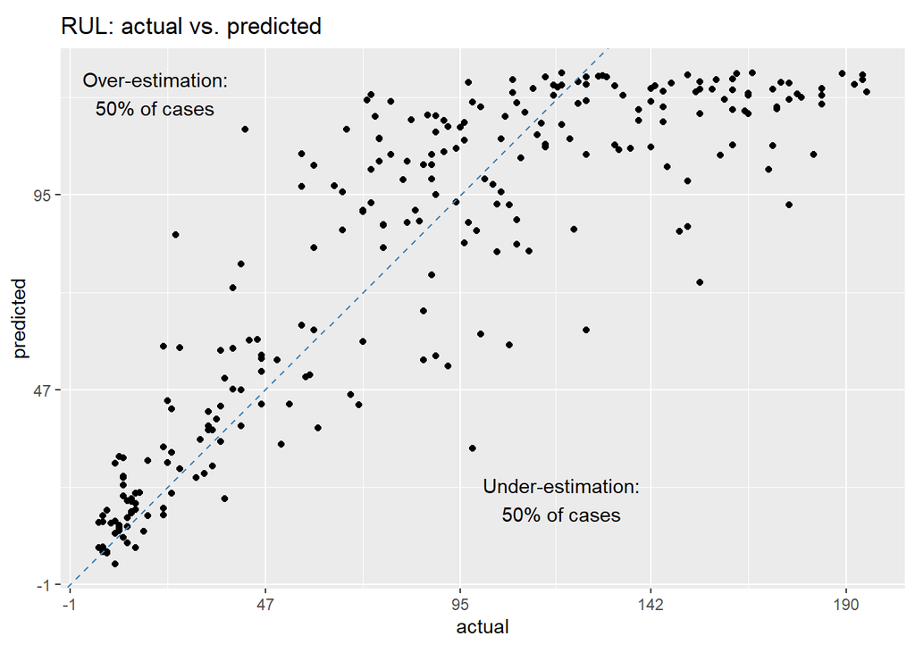

```r
(plot_pred_vs_act(xgb_fit,test_data4_s_dums))
```

## 4.2 Summary of results and validation scores

We can now summarize the results and see the validation scores of the trained XGB and RF models.

```r
xgb_fit_simp <- readRDS(here("objects/xgb_trained_04_01_B.rds"))
xgb_fit_comp <- readRDS(here("objects/xgb_trained_04_01_comp_cap.rds"))

rf_fit_simp <- readRDS(here("objects/rf_trained_04_01.rds"))
rf_fit_comp <- readRDS(here("objects/rf_trained_04_01_comp_cap.rds"))

print('Cross Validation scores:')
lapply(list(xgb_fit_simp = xgb_fit_simp,
            xgb_fit_comp = xgb_fit_comp,
            rf_fit_simp = rf_fit_simp,
            rf_fit_comp = rf_fit_comp),
       function(x)  x$results %>% arrange(RMSE) %>% head(1) %>% .[['RMSE']])
```

```
## [1] "Cross Validation scores:"
## $xgb_fit_simp
## [1] 18.02295
##
## $xgb_fit_comp
## [1] 17.38151
##
## $rf_fit_simp
## [1] 17.95183
##
## $rf_fit_comp
## [1] 17.24392
```

We can conclude that the best performing model is Random Forest. Let’s see if the same occurs on validation set:

```r
print("Validation scores (on the test set):")

lapply(list(xgb_fit_simp = xgb_fit_simp,
            rf_fit_simp = rf_fit_simp),
       function(x)  get_validation_reg_score(x,test_data1_s))

lapply(list(xgb_fit_comp = xgb_fit_comp,
            rf_fit_comp = rf_fit_comp),
       function(x)  get_validation_reg_score(x,test_data4_s_dums))
```

```
## [1] "Validation scores (on the test set):"
## $xgb_fit_simp
##       RMSE   Rsquared        MAE
## 17.5471565  0.8229686 12.5824834
##
## $rf_fit_simp
##       RMSE   Rsquared        MAE
## 17.6040936  0.8256865 12.8503218
##
## $xgb_fit_comp
##       RMSE   Rsquared        MAE
## 29.9792522  0.7284504 22.2776087
##
## $rf_fit_comp
##       RMSE   Rsquared        MAE
## 30.1539035  0.7316479 22.6700963
```

We can see that actually the results on the validation score are reversed! Without surprise, the models perform worse on the complicated dataset.